# 7 Exploratory Data Analysis

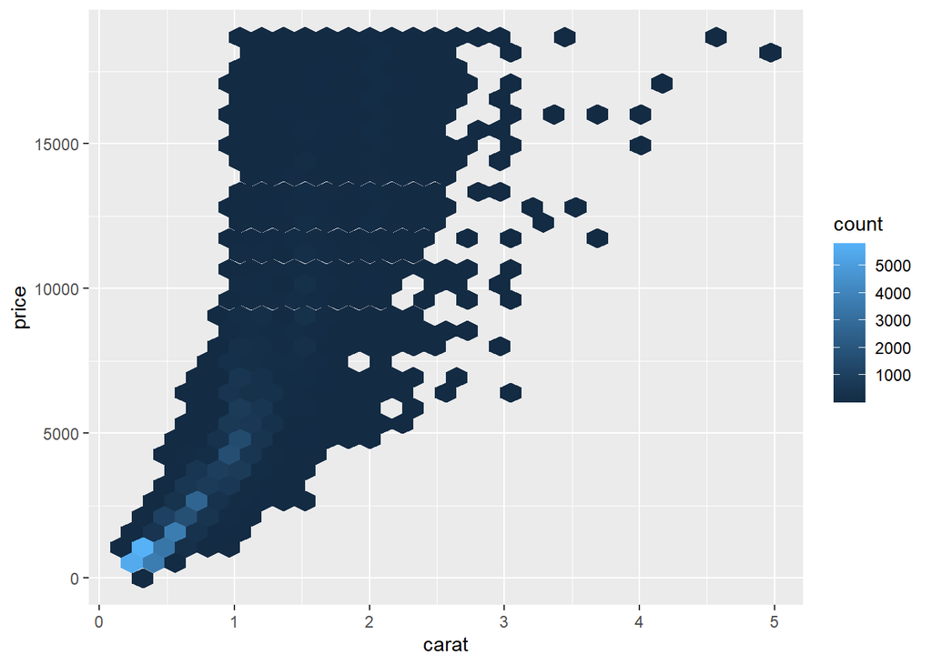

```r
ggplot(data = diamonds) +
  geom_hex(mapping = aes(x = carat, y = price))
```

Outra maneira é agrupar uma das variáveis continuas para que se comporte como catégorica. cut_width(x,width) faz a divisão de uma variável continua de maneira que essa seja divida em varios grupos com espessura do intervalo = width.

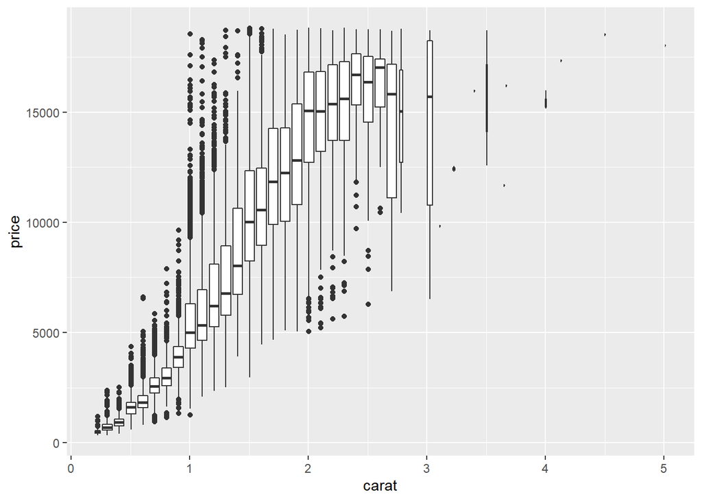

```r
ggplot(diamonds) + geom_boxplot(aes(x=carat,y=price,group=cut_width(carat,0.1)))
```

Podemos fazer com que a largura dos boxplots seja proporcional a quantidade de pontos nele, dessa maneira sabemos onde mais pontos se concentram.

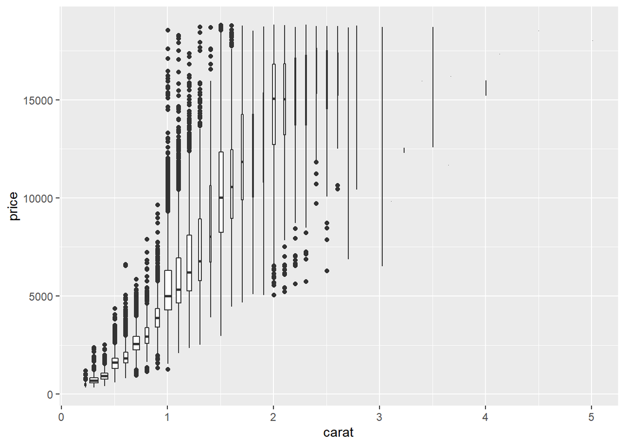

```r
ggplot(diamonds) + geom_boxplot(aes(x=carat,y=price,group=cut_width(carat,0.1)),varwidth = T)
```

Podemos também definir quantas bins devem existir no gráfico, com o argumentocut_number definimos a quantidade de bins e todas devem ter a mesma quantidade de dados, isso gera boxplots de largura diferente.

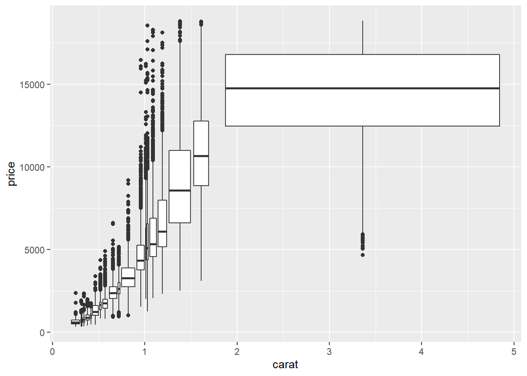

```r
ggplot(diamonds) + geom_boxplot(aes(x=carat,y=price,group=cut_number(carat,20)))
```

### Exercícios 7.5.3.1

1. Podemos fazer a visualização de duas contínuas por meio de um poligono de frequencia. O que deve ser considerado quando usamos cut_width() e cut_number()? Como isso impacta a visualização de carat vs price.

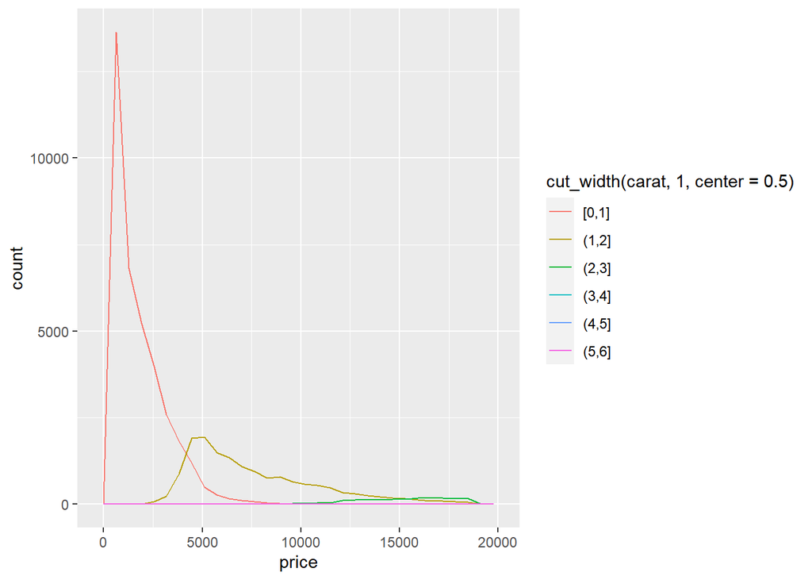

```r
ggplot(diamonds) + geom_freqpoly(aes(color=cut_width(carat,1,center=0.5),x=price))
```

Quando fazemos a divisão dessa maneira temos a distribuição de cada intervalo com todos os intervalos contendo tamanho igual.

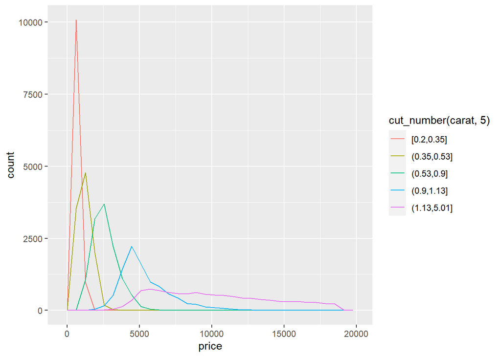

```r
ggplot(diamonds) + geom_freqpoly(aes(color=cut_number(carat,5),x=price))
```

Quando fazemos a divisão dessa maneira temos todos grupo com quantidades iguais de observações e podemos perceber melhor que pesos maiores refletem preços mais caros.

2. Visualize a distribuição de quilates dividida pro grupos de preço.

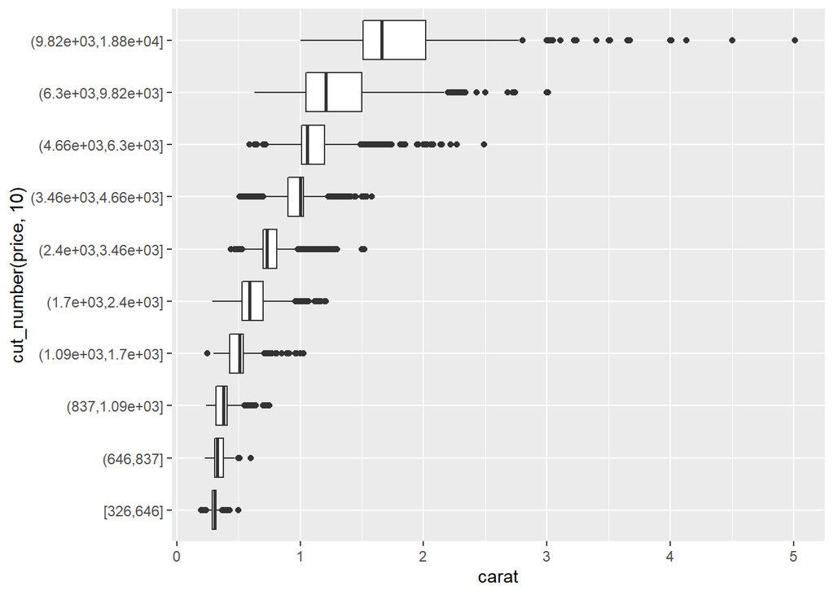

```r
ggplot(diamonds) + geom_boxplot(aes(y=carat,x=cut_number(price,10))) + coord_flip()
```

3. Como a distribuição de preço de grandes se compara com diamantes pequenos?

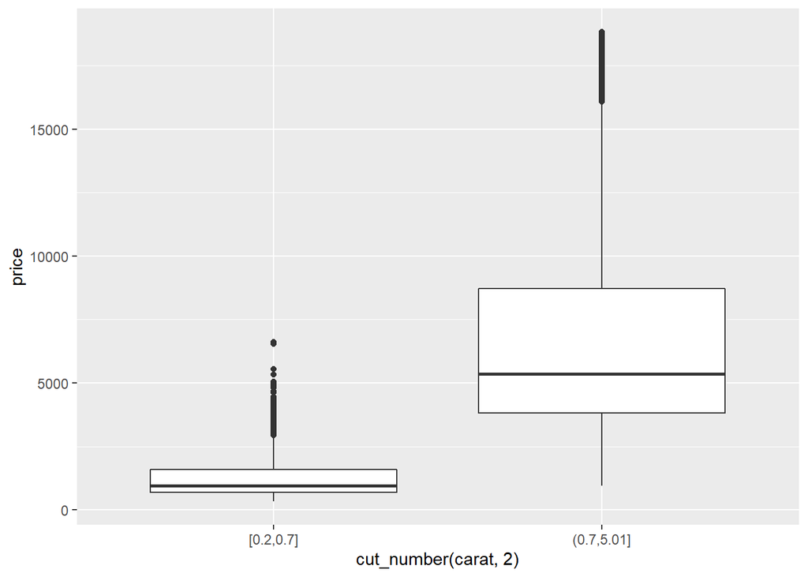

```r
ggplot(diamonds) + geom_boxplot(aes(x=cut_number(carat,2),y=price))
```

Os diamantes maiores tendem a ser mais caros e variarem mais, já esperava esses resultados dado que sabia que o fator mais influente no preço.

4. Visualize a distribuição combinada de cut, carat e price.

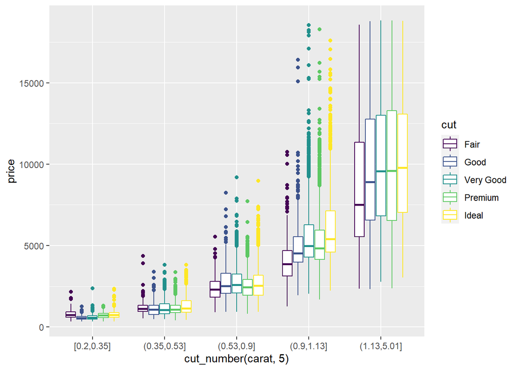

```r
ggplot(diamonds) + geom_boxplot(aes(cut_number(carat,5),price,color=cut))
```

O que mais afeta realmente é o peso do diamante, porém o corte também afeta, em diamantes do mesmo peso a tendencia é que o preço seja maior para cortes melhores.

5. Gráficos de dispersão apresentam outliers bem. Por exemplo:

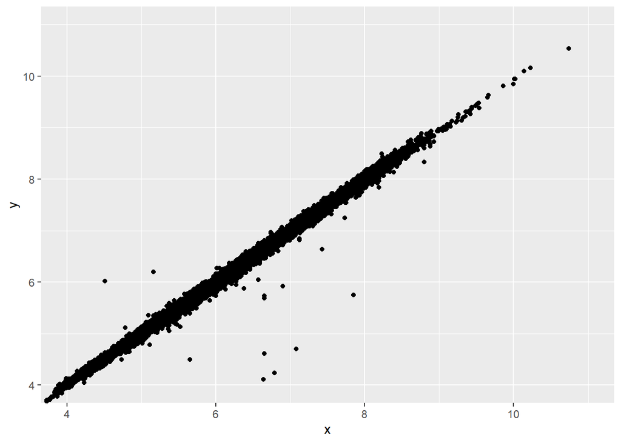

```r
ggplot(data = diamonds) +
  geom_point(mapping = aes(x = x, y = y)) +
  coord_cartesian(xlim = c(4, 11), ylim = c(4, 11))
```

Esse gráfico apresenta outliers que quando fossem visualizados individualmente em y seriam normais porém a combinação de x e y é não usual. O uso de gráficos de dispersão são melhores que divididos em classes nesse caso pois permitem indentificar esses pontos com mais facilidade.

## 7.6 Patterns and Models

Padrões em dados indicam que pode existir uma relação entre duas variáveis. Se você encontra um padrão se pergunte:

- Esse padrão pode ser gerado por coincidência (Aleatoriedade)?
- Como você pode descrever a relação indicada pelo padrão?
- Quão forte é a relação indicada pelo padrão?
- Quais outras variáveis podem afetar a relação?
- A relação é alterada ao analisarmos diferentes subgrupos dos dados?

A covariação gera a possibilidade de usar o valor de uma variável para fazer previsões sobre a outra. Em casos que uma é consequência da outra podemos ainda controlar o valor de uma controlando a outra.

Modelos são ferramentas para extrair padrões de dados, podemos usar modelos para definir a relação de duas variáveis sem a interferencia de uma terceira, ou podemos fazer a previsão de uma variável baseado em diversas outras variáveis ao mesmo tempo.

## 7.7 ggplot2 calls

A partir dessa parte do livro os códigos serão mais concisos e não serão escritos os nomes de todos argumentos conforme anteriormente.

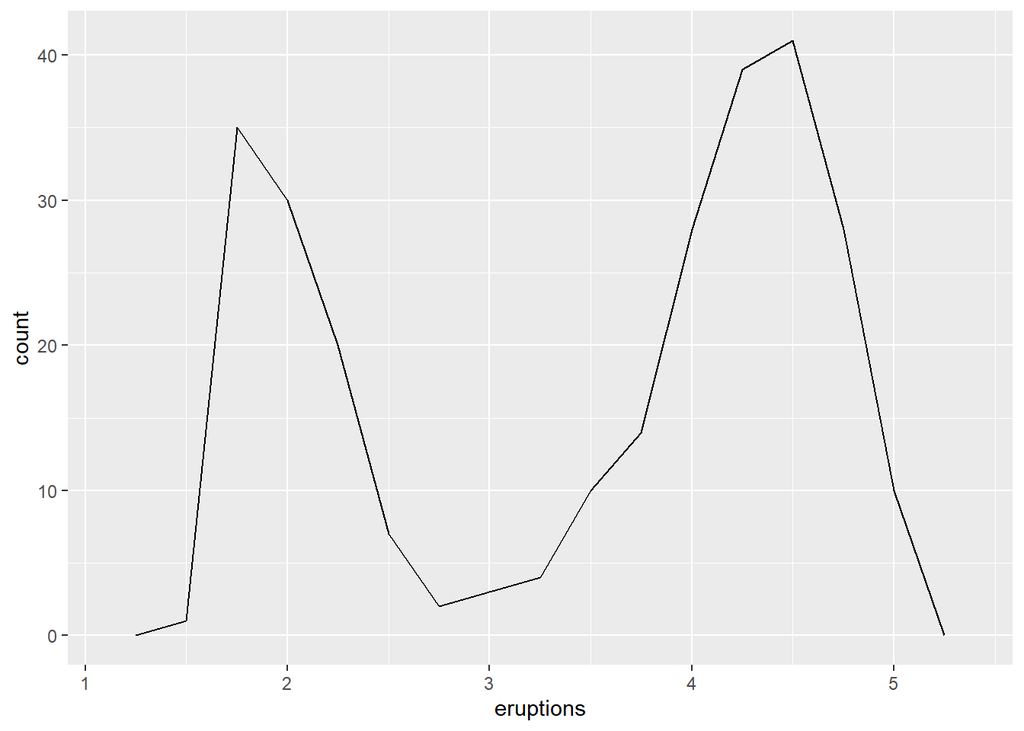

```r
ggplot(data = faithful, mapping = aes(x = eruptions)) +
  geom_freqpoly(binwidth = 0.25)
```

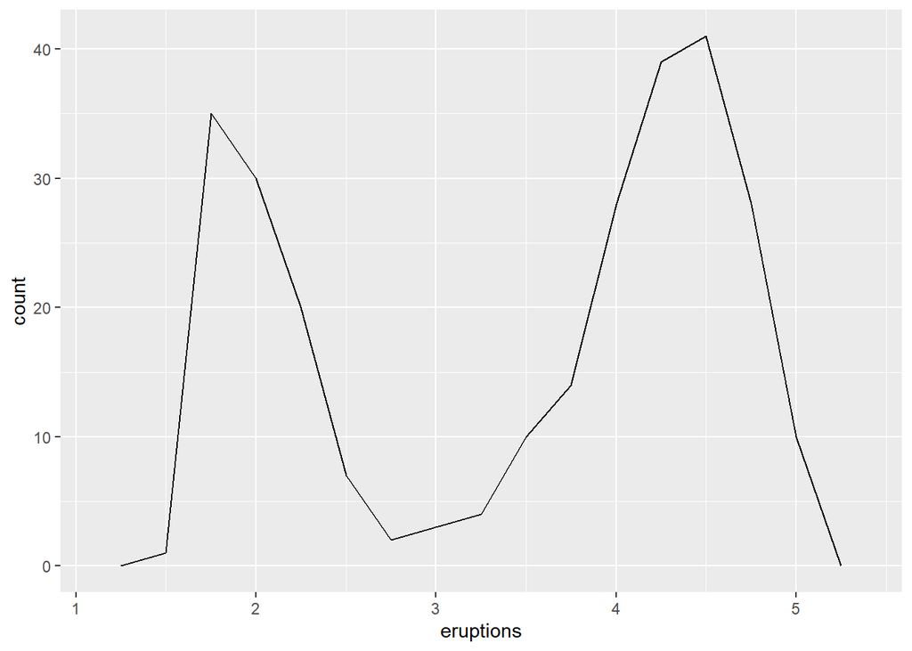

```r
# SERÁ

ggplot(faithful, aes(eruptions)) +
  geom_freqpoly(binwidth = 0.25)
```